# Project (Assignment 3): Unsupervised Learning (E-Commerce Orders)

This notebook is your working template for **Assignment 3**.

**Note:** This assessment comprises two parts: question-guided processing/modeling (Unsupervised learning) and free-form exploration.

**Total Marks: 20**

You will:

- Continue working with the expanded dataset from Assignment 1
- Perform **clustering** to identify similar order types
- Apply **market basket analysis** (association rule mining)
- Write up findings throughout the notebook
- Publish your analysis as a github.io page

Work **top-to-bottom**. Complete each task in order before moving on.

Group number on Canvas: 1

| Student ID (AxxxxxxxZ) | NUSNet ID (exxxxxxx) | Name (as it appears on Canvas) |
| --- | --- | --- |
| A0314560M | e1504029 | Zackarias Chia Yue LIn |
| A0167041M | e0175474 | Javen Tan Chun Quan |
| A0201688B | e0415497 | Pratheeb Ganesanathan |

## Setup

Run the cell below to import the required Python packages.

```python
# %pip install mlxtend
```

```python
import pandas as pd
import numpy as np
import matplotlib.pyplot as plt
import seaborn as sns

from sklearn.model_selection import train_test_split
from sklearn.preprocessing import StandardScaler
from sklearn.cluster import KMeans

from mlxtend.preprocessing import TransactionEncoder
from mlxtend.frequent_patterns import apriori, association_rules

plt.style.use('seaborn-v0_8')
```

## Load Your Cleaned Dataset from Assignment 1

Load the cleaned and expanded dataset you created in Assignment 1 (and potentially modified in Assignment 2).

```python
# ANSWER: Load your cleaned dataset
df = pd.read_csv('ecommerce_orders_cleaned.csv') # Loading as a dataset
```

## Task: Unsupervised Learning

### Objective

In this task, you will work on unsupervised learning and support your analysis with visualization. Perform clustering to identify **similar orders** and generate **order type recommendations** based on their characteristics. An order type cluster represents a group of orders with similar purchasing patterns, value structures, and composition.

### 1: Data Preprocessing for Unsupervised Learning [1 Mark]

Goal: Create DataFrames that contain one row per order with features suitable for both clustering and association mining.

#### 1-1 Create `all_orders_df` (one row per order)

Create a new DataFrame called `all_orders_df` with the following columns:

Identifier:

- `order_id` — Unique identifier of the order
- `basket_size` — Monetary value of the order (from `order_total_value`)
- `basket_qty` — Number of items in the order (from `num_items`)
- `freight_ratio` — Proportion of the order value that is freight (computed as `total_freight_value / order_total_value`)
- `product_diversity` — How varied the basket is in terms of product types (computed as `num_unique_products / num_items`)
- `top_product_category` — The dominant product category in the order
- `payment_type` — The payment method used
- `order_size_category` — The order size category (Small/Medium/Large)

Notes:

- `all_orders_df` must have exactly one row per `order_id`.
- No missing values should remain in these columns after preprocessing (apply reasonable handling if needed).
- Handle potential division issues appropriately (e.g., orders with zero values).
- Display the first 10 rows of `all_orders_df`, its shape, and data types.

```python
# Choosing the relevant columns needed to create the new df
all_orders_df = df[['order_id', 'order_total_value', 'num_items', 'total_freight_value',
                     'num_unique_products', 'top_product_category', 'payment_type',
                     'order_size_category']].copy()

all_orders_df = all_orders_df.drop_duplicates(subset='order_id') # Drop duplicate order id

# Creating the relevant metrics and columns based on the descriptions provided
all_orders_df['freight_ratio'] = all_orders_df['total_freight_value'] / all_orders_df['order_total_value'] #Freight ratio
all_orders_df['product_diversity'] = all_orders_df['num_unique_products'] / all_orders_df['num_items'] #Product Diversity

#Fill all missing values with 0 given a lack of information for numeric columns
all_orders_df['freight_ratio'] = all_orders_df['freight_ratio'].fillna(0)
all_orders_df['product_diversity'] = all_orders_df['product_diversity'].fillna(0)

#For those that are category, use 'Unknown' as a separate distinct category
all_orders_df['top_product_category'] = all_orders_df['top_product_category'].fillna('Unknown')
all_orders_df['payment_type'] = all_orders_df['payment_type'].fillna('Unknown')
all_orders_df['order_size_category'] = all_orders_df['order_size_category'].fillna('Unknown')

#Renaming columns
all_orders_df = all_orders_df.rename(columns={
    'order_total_value': 'basket_size',
    'num_items': 'basket_qty'
})

# Selecting the relevant columns and dropping all not needed columns
all_orders_df = all_orders_df[['order_id', 'basket_size', 'basket_qty', 'freight_ratio',
                                'product_diversity', 'top_product_category', 'payment_type',
                                'order_size_category']]

all_orders_df = all_orders_df.reset_index(drop=True)

print(all_orders_df.head(10))
print(all_orders_df.shape)
print(all_orders_df.dtypes)
```

```
        order_id  basket_size  basket_qty  freight_ratio  product_diversity  \
0  sdv-id-whzjUX   744.312535           1       0.092421           1.000000
1  sdv-id-dbopoJ  1556.667902           1       0.009889           1.000000
2  sdv-id-FSEOvM    62.060506           1       0.302145           1.000000
3  sdv-id-bQcBUR    73.873470           1       0.117375           1.000000
4  sdv-id-MPxIXB   361.961537           3       0.095953           1.000000
5  sdv-id-ySodbB   867.750230           7       0.204442           0.857143
6  sdv-id-wdwBrk    55.965822           2       0.285101           0.500000
7  sdv-id-maBYtk   170.295452           3       0.089290           1.000000
8  sdv-id-oodUXj    83.065603           1       0.236471           1.000000
9  sdv-id-zroJIL    98.250248           1       0.369709           1.000000

              top_product_category payment_type order_size_category
0  construction_tools_construction      voucher               Small
1                    health_beauty  credit_card               Small
2              luggage_accessories   debit_card               Small
3            computers_accessories  credit_card               Small
4                         pet_shop      voucher              Medium
5                   sports_leisure      voucher               Large
6                             toys       points               Small
7            computers_accessories      voucher              Medium
8                  furniture_decor      voucher               Small
9         fashion_bags_accessories       points               Small
(46287, 8)
order_id                 object
basket_size             float64
basket_qty                int64
freight_ratio           float64
product_diversity       float64
top_product_category     object
payment_type             object
order_size_category      object
dtype: object
```

#### 1.2 Create `orders_analysis_df`

- Use `train_test_split` from sklearn to split the data in `all_orders_df`.
- Set `test_size=0.3` (keep 30% of data for analysis) and `random_state=37` for reproducibility.
- Assign the **test set** to the variable `orders_analysis_df`.

Display the shape of `orders_analysis_df` and show its first 10 rows.

```python
# 1.2 ANSWER: Create orders_analysis_df using train_test_split
from sklearn.model_selection import train_test_split

#Set Random State to 37
random_state = 37

#Create split between train and test, with test size of 0.3 and random state =37
train_set, orders_analysis_df = train_test_split(all_orders_df, test_size=0.3, random_state=random_state)

print(orders_analysis_df.shape)
print(orders_analysis_df.head(10))
```

```
(13887, 8)
            order_id  basket_size  basket_qty  freight_ratio  \
1882   sdv-id-ISddRn   132.611695           1       0.126285
40995  sdv-id-GmlErp   730.510053           6       0.075288
40104  sdv-id-BWpket   632.486142           1       0.051262
25808  sdv-id-krmbPT    47.102393           1       0.248932
23294  sdv-id-vhfMmG   133.285008           1       0.135860
7160   sdv-id-kcTYfM   403.696187           2       0.079065
7180   sdv-id-tFFFCg   211.465148           2       0.162263
20801  sdv-id-KgDKAA    57.520738           1       0.228879
19879  sdv-id-cfCjEB   576.212699           3       0.056350
39874  sdv-id-uxRZME   141.772602           2       0.200719

       product_diversity      top_product_category payment_type  \
1882            1.000000        christmas_supplies      voucher
```

[output cut: 21 more lines]

### 2: Determine the Optimal Number of Clusters [3 Marks]

#### 2-1 Run K-Means for Different Cluster Numbers

- Use **only the four numerical features** from `orders_analysis_df` (`basket_size`, `basket_qty`, `freight_ratio`, `product_diversity`) for clustering.
- Run K-means clustering from **k = 3 to 9** clusters.
- Important: First scale the numerical features using `StandardScaler` before fitting K-means.
- In each run, calculate the **inertia** of the cluster and store the values for each k (3 to 9) in a list or table.

Inertia is a measure of how tightly packed the clusters are. It is the sum of squared distances between each point and its assigned cluster center (centroid). Lower inertia indicates that the clusters are more compact, and the points are closer to their centroids, suggesting better clustering.

```python
# 2.1 ANSWER: Run K-means for k=3 to 9 and calculate inertia
from sklearn.preprocessing import StandardScaler
from sklearn.cluster import KMeans


# Choosing the numerical columns and adding it to a new dataframe
numerical_features = orders_analysis_df[['basket_size', 'basket_qty', 'freight_ratio', 'product_diversity']]

# Creating the scaler class and scale the features accordingly
scaler = StandardScaler()
scaled_features = scaler.fit_transform(numerical_features)

# For-Loop between 3-9 clusters and adding each inertia value for each loop to the list.
inertia_values = []

for k in range(3, 10):
    kmeans = KMeans(n_clusters=k, random_state=random_state)
    kmeans.fit(scaled_features) #Fit each cluster
    inertia_values.append(kmeans.inertia_)

print(inertia_values)
```

```
[28884.28745954533, 21464.490872418446, 17303.164621971413, 15014.005306899855, 13530.944386713203, 11762.816172512355, 10585.957146911864]
```

#### 2.2 Elbow Method for Optimal Clusters

- Plot the **inertia** (y-axis) against the **number of clusters** (x-axis) to identify the optimal number of clusters using the **Elbow method**.

The Elbow Method helps in selecting the number of clusters by identifying where the inertia starts to decrease more slowly.

- Based on the Elbow plot, **choose the optimal number of clusters** and state your choice clearly.

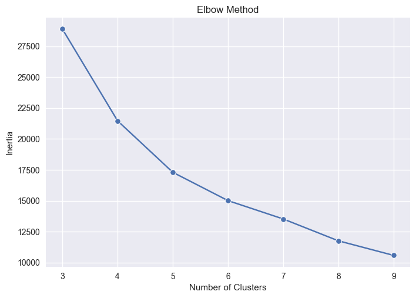

```python
# 2.2 ANSWER: Create Elbow plot


# Creating a line plot to show the inertia values for each cluster value
sns.lineplot(x=range(3, 10), y=inertia_values, marker='o')

plt.title('Elbow Method')
plt.xlabel('Number of Clusters')
plt.ylabel('Inertia')
plt.show()
```

Based on the graph, the optimal number of clusters seem to be 6 as the marginal rate of inertia starts to decline significantly past that.

### 3: Cluster Analysis and Visualization [3 Marks]

#### 3.1 Identify the Cluster Number for Each Order

- Create a K-means model using the four numerical features from `all_orders_df` and the optimal number of clusters identified in Task 2.
- Fit the model on the scaled numerical features.
- Use the fitted model to assign a cluster number to each order and add a new column called `cluster` to `all_orders_df`.
- Show the first 10 rows of `all_orders_df` to verify cluster assignment.

```python
# 3.1 ANSWER: Fit K-means with optimal k and assign clusters


# Chose numeric features
numerical_features_all = all_orders_df[['basket_size', 'basket_qty', 'freight_ratio', 'product_diversity']]

scaled_features_all = scaler.fit_transform(numerical_features_all) #Scale them

# Set the cluster number to 6 and get the labels for each order once it has been clustered and add them to the dataframe
kmeans = KMeans(n_clusters=6, random_state=random_state)
kmeans.fit(scaled_features_all)

all_orders_df['cluster'] = kmeans.labels_

print(all_orders_df.head(10))
```

```
        order_id  basket_size  basket_qty  freight_ratio  product_diversity  \
0  sdv-id-whzjUX   744.312535           1       0.092421           1.000000
1  sdv-id-dbopoJ  1556.667902           1       0.009889           1.000000
2  sdv-id-FSEOvM    62.060506           1       0.302145           1.000000
3  sdv-id-bQcBUR    73.873470           1       0.117375           1.000000
4  sdv-id-MPxIXB   361.961537           3       0.095953           1.000000
5  sdv-id-ySodbB   867.750230           7       0.204442           0.857143
6  sdv-id-wdwBrk    55.965822           2       0.285101           0.500000
7  sdv-id-maBYtk   170.295452           3       0.089290           1.000000
8  sdv-id-oodUXj    83.065603           1       0.236471           1.000000
9  sdv-id-zroJIL    98.250248           1       0.369709           1.000000

              top_product_category payment_type order_size_category  cluster
0  construction_tools_construction      voucher               Small        0
1                    health_beauty  credit_card               Small        4
2              luggage_accessories   debit_card               Small        1
3            computers_accessories  credit_card               Small        0
4                         pet_shop      voucher              Medium        0
5                   sports_leisure      voucher               Large        5
6                             toys       points               Small        2
7            computers_accessories      voucher              Medium        0
8                  furniture_decor      voucher               Small        3
9         fashion_bags_accessories       points               Small        1
```

#### 3.2 Visualize the Clusters

Create two visualizations to understand your clusters:

- **Visualization 1: Cluster Profile Heatmap**
  - Visualize the cluster profiles using a heatmap to understand the average characteristics of each segment.
  - Step 1: Compute the mean of the four numerical features (`basket_size`, `basket_qty`, `freight_ratio`, `product_diversity`) for each cluster.
  - Step 2: Scale these means (e.g., using `StandardScaler` to calculate Z-scores) so that different units (price vs. count) can be compared directly.
  - Step 3: Plot the scaled means as a heatmap:
    - X-axis: Cluster number
    - Y-axis: Feature name
    - Color: Use a diverging colormap (e.g., `RdBu_r`) to distinguish features that are above average (positive Z-score) from those that are below average (negative Z-score)
    - Annotation: Display the Z-score values in each cell
  - Add a clear title.
- **Visualization 2: Cluster Size Distribution**
  - Create a bar chart showing the number of orders in each cluster.
    - X-axis: Cluster number (0, 1, 2, ...)
    - Y-axis: Count of orders
    - This helps you understand if clusters are balanced or if some clusters dominate.
  - Add a title and axis labels.

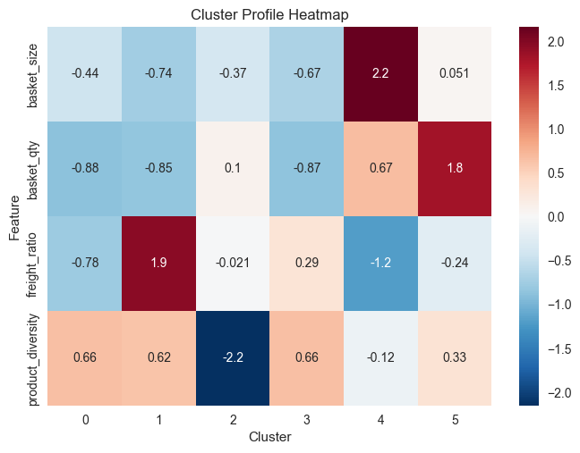

```python
# 3.2 ANSWER: Visualization 1 - Cluster profile heatmap

# Create a heatmap using seaborn based on the numeric features
fig1, ax1 = plt.subplots()

cluster_means = all_orders_df.groupby('cluster')[['basket_size', 'basket_qty', 'freight_ratio', 'product_diversity']].mean() # Get the mean based on each cluster

scaled_means = scaler.fit_transform(cluster_means)
scaled_means_df = pd.DataFrame(scaled_means, index=cluster_means.index, columns=cluster_means.columns) # Scale the mean of each cluster and add it to a new dataframe

#Plot the heatmap
sns.heatmap(scaled_means_df.T, annot=True, cmap='RdBu_r', ax=ax1)
ax1.set_title('Cluster Profile Heatmap')
ax1.set_xlabel('Cluster')
ax1.set_ylabel('Feature')

plt.show()
```

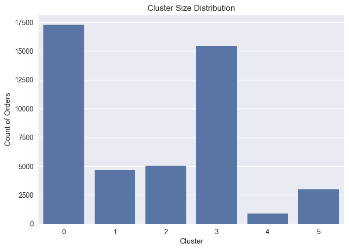

```python
# 3.2 ANSWER: Visualization 2 - Cluster size distribution

fig2, ax2 = plt.subplots()

cluster_counts = all_orders_df['cluster'].value_counts().sort_index() #Count the number of orders based on the cluster and sort them for good plotting
sns.barplot(x=cluster_counts.index, y=cluster_counts.values, ax=ax2)
ax2.set_title('Cluster Size Distribution')
ax2.set_xlabel('Cluster')
ax2.set_ylabel('Count of Orders')

plt.show()
```

**Briefly comment (2-3 sentences) on:**

- How well separated do the clusters appear based on the heatmap?
- Which features seem to have the most significant impact on defining the clusters? Why might this be the case?
- Based on the visualizations that you have generated, comment on the nature of the clusters and what it implies for an e-commerce business

**3.2 ANSWER:**

1. Based on the heatmap, in general, the clusters seem to be quite well separated. The main thing is that between each clusters, the scaled means differ quite a lot with a mix of positive and negative z scores. The numbers also do not hover around 0, indicating that the clusters are well separated as well.
2. Based on the heatmap, freight ratio seems to have the most significant impact in defining the clusters as the values significantly contrast greatly between each cluster. In second place would be basket size which smaller yet still differentiable values between each clusters. Freight ratio could be significant as some orders have very low freight costs relative to their value (e.g. expensive electronics) while others have freight costs that are nearly equal to the product value. A high freight ratio could also mean the customer lives in a remote region, the seller is far away, or the product is heavy/bulky. These behavioral differences create natural groupings that other features cannot capture. Basket Size could also be significant as it may indicate different demographics of users based on the type of items they buy based on their purchasing power. Depending on the type of items being sold on the platform, it could also indicate the types of items that are being ordered, from very small cheap items to large bulky orders.
3. The majority of clusters fall within either 0 or 3. These tends to be the average users of the site, given that their scaled values are very similar with the exception of the basket size and freight ratio. As mentioned above, this could be separated into customers who buy cheap items vs those who buy more expensive items, or those that live in remote regions vs those in more accessible regions. For Cluster 1, the freight ratio is very high, which could indicate this group of customers live in areas that have high shipping costs and hence why freight costs are high. This may mean that the e-commerce business may want to look into cheaper ways of shipping in order to better attract customers in these areas. For Cluster 2, it seems that that this group of customers tend to buy the same item. The e-commerce business may wish to introduce bulk discounts to attract these group of customers to incentive them to buy more of the same items. Cluster 4 is the smallest but has the biggest basket size, which indicates high spenders who shop a lot. The business might consider recommending more expensive3 products to them in order to entice them to buy more given their high purchasing power. Lastly, Cluster 5 seems to be differentiated by their big basket quantity, indicating that these group buy a lot of cheap value products. The business might consider recommending more bundled or complementary goods to these group of customers to entice them to buy more varied items.

### 4: Market Basket Analysis (Association Rule Mining) [8 Marks]

#### 4.1 Context: What is Market Basket Analysis?

Market Basket Analysis is an unsupervised learning technique that identifies which products, categories, or attributes are frequently observed together. In e-commerce, this helps answer questions such as:

- "Which payment methods are preferred for which product categories?"
- "Do certain order sizes correlate with specific product types?"
- "What are the multi-dimensional patterns across category, payment, and order size?"

Association rules are commonly described using three key metrics:

- **Support**: How frequently a pattern occurs (0-1 scale)
- **Confidence**: Likelihood of the consequent given the antecedent (0-1 scale)
- **Lift**: How much more likely the rule is compared to random chance (> 1 indicates a positive association)

The Apriori algorithm discovers frequent itemsets and then generates association rules from them.

In this task, you will perform Market Basket Analysis using the categorical features from `all_orders_df` to discover multi-dimensional associations between product category, payment type, and order size category.

#### 4.2 Prepare Transaction Data [1 Mark]

Convert each order in `all_orders_df` into a simple "basket" representation.

Create a Python list called `transactions`, where each element represents one order and contains exactly three string items constructed from that order:

- `cat_{top_product_category}` (e.g., `cat_electronics`, `cat_furniture_decor`)
- `pay_{payment_type}` (e.g., `pay_credit_card`, `pay_boleto`)
- `size_{order_size_category}` (e.g., `size_Small`, `size_Large`)

After constructing `transactions`, display the first 5 transactions to verify the format.

```python
# 4.2 ANSWER: Create transaction list
transactions = []

for index, row in all_orders_df.iterrows(): #For each row, create the category, payment type and order size based on the instructions
    transaction = [
        'cat_' + str(row['top_product_category']),
        'pay_' + str(row['payment_type']),
        'size_' + str(row['order_size_category'])
    ]
    transactions.append(transaction) #Add it to the list

print(transactions[:5])
```

```
[['cat_construction_tools_construction', 'pay_voucher', 'size_Small'], ['cat_health_beauty', 'pay_credit_card', 'size_Small'], ['cat_luggage_accessories', 'pay_debit_card', 'size_Small'], ['cat_computers_accessories', 'pay_credit_card', 'size_Small'], ['cat_pet_shop', 'pay_voucher', 'size_Medium']]
```

#### 4.3 Encode Transactions and Apply Apriori Algorithm [2 Marks]

Use the `mlxtend` library to discover frequent itemsets and generate association rules.

- Step 1: Encode transactions using `TransactionEncoder` and display the shape of the encoded DataFrame.
- Step 2: Apply `apriori()` with `min_support = 0.01` and `use_colnames = True`, then display the number of frequent itemsets found.
- Step 3: Generate association rules using `association_rules()` with `metric = 'lift'` and `min_threshold = 1.0`, then display the number of rules generated.

```python
# 4.3 ANSWER: Step 1 - Encode transactions
te = TransactionEncoder()
te_array = te.fit_transform(transactions) # Encode each transaction in the list
te_df = pd.DataFrame(te_array, columns=te.columns_)

print(te_df.shape)
```

```
(46287, 79)
```

```python
# 4.3 ANSWER: Step 2 - Apply Apriori

frequent_itemsets = apriori(te_df, min_support=0.01, use_colnames=True)
print(len(frequent_itemsets))
```

```
102
```

```python
# 4.3 ANSWER: Step 3 - Generate association rules
rules = association_rules(frequent_itemsets, metric='lift', min_threshold=1.0)
print(len(rules))
```

```
138
```

#### 4.4 Extract and Display Top 10 Rules [1 Mark]

Sort the association rules by **lift** in descending order and display the top 10 rules in a table showing:

- Antecedents (left-hand side of rule)
- Consequents (right-hand side of rule)
- Support
- Confidence
- Lift

Example rule output and interpretation:

| antecedents | consequents | support | confidence | lift |
| --- | --- | --- | --- | --- |
| (cat_furniture_decor, size_Large) | (pay_credit_card) | 0.042 | 0.756 | 1.84 |

"Customers who purchase **furniture** in **large orders** have a **75.6% probability** (confidence) of paying with a **credit card**. This behavior is **1.84 times more likely** (lift) than the general probability of using a credit card.

```python
# 4.4 ANSWER: Display top 10 rules by lift

top_10_rules = rules.sort_values('lift', ascending=False).head(10) # Sort the top 10 rules based on lift

top_10_rules = top_10_rules[['antecedents', 'consequents', 'support', 'confidence', 'lift']].reset_index(drop=True) # Choose the relevant columns

print(top_10_rules)
```

```
                             antecedents  \
0                           (size_Large)
1                  (cat_furniture_decor)
2         (size_Medium, pay_credit_card)
3                   (cat_bed_bath_table)
4                          (size_Medium)
5  (cat_bed_bath_table, pay_credit_card)
6                  (cat_furniture_decor)
7                          (size_Medium)
8                   (cat_bed_bath_table)
9                          (size_Medium)

                             consequents   support  confidence      lift
0                  (cat_furniture_decor)  0.014583    0.392899  5.328480
1                           (size_Large)  0.014583    0.197773  5.328480
2                   (cat_bed_bath_table)  0.016851    0.280576  2.023212
3         (size_Medium, pay_credit_card)  0.016851    0.121514  2.023212
4  (cat_bed_bath_table, pay_credit_card)  0.016851    0.171693  1.757439
5                          (size_Medium)  0.016851    0.172490  1.757439
6                          (size_Medium)  0.012660    0.171696  1.749354
7                  (cat_furniture_decor)  0.012660    0.128990  1.749354
8                          (size_Medium)  0.022749    0.164044  1.671388
9                   (cat_bed_bath_table)  0.022749    0.231785  1.671388
```

```python
top_10_rules
```

|  | antecedents | consequents | support | confidence | lift |
| --- | --- | --- | --- | --- | --- |
| 0 | (size_Large) | (cat_furniture_decor) | 0.014583 | 0.392899 | 5.328480 |
| 1 | (cat_furniture_decor) | (size_Large) | 0.014583 | 0.197773 | 5.328480 |
| 2 | (size_Medium, pay_credit_card) | (cat_bed_bath_table) | 0.016851 | 0.280576 | 2.023212 |
| 3 | (cat_bed_bath_table) | (size_Medium, pay_credit_card) | 0.016851 | 0.121514 | 2.023212 |
| 4 | (size_Medium) | (cat_bed_bath_table, pay_credit_card) | 0.016851 | 0.171693 | 1.757439 |
| 5 | (cat_bed_bath_table, pay_credit_card) | (size_Medium) | 0.016851 | 0.172490 | 1.757439 |
| 6 | (cat_furniture_decor) | (size_Medium) | 0.012660 | 0.171696 | 1.749354 |
| 7 | (size_Medium) | (cat_furniture_decor) | 0.012660 | 0.128990 | 1.749354 |
| 8 | (cat_bed_bath_table) | (size_Medium) | 0.022749 | 0.164044 | 1.671388 |
| 9 | (size_Medium) | (cat_bed_bath_table) | 0.022749 | 0.231785 | 1.671388 |

#### 4.5 Interpretation (3-4 sentences) [3 Marks]

Write a brief interpretation explaining:

- What the top 3 unique rules tell you about customer behavior
- Which combinations are most strongly associated (highest lift)
- Why these associations might exist (business intuition)
- Change the min_support value to 0.005 and 0.3 and comment on any changes in the rules identified

**4.5 ANSWER:**

#### 4.6 Business Recommendations (2-3 bullet points) [1 Mark]

Based on the discovered associations, provide actionable business recommendations for an e-commerce firm.

**4.6 ANSWER:**

- When a customer places a large order, it may be most likely that they are shopping for furniture and decor. Actively recommend furniture and decor items through upselling or bundling since this behavior is 5.33x more likely. Offer free or discounted shipping thresholds specifically for furniture and decor, since these items are heavy and freight costs are likely a barrier to purchase.
- Target credit card users with medium-sized orders with personalized recommendations for bed, bath and table products. Since this group is already 2x more likely to buy these items, a well-timed recommendation could convert them easily.
- For medium order customers who have not yet selected a payment method, nudge them towards credit card payment by offering small incentives such as discounts or reward points, since this combination is 1.76x more likely to occur naturally.

#### Tips

- Rules with **lift > 1.5** are considered strong associations; rules with **lift > 2.0** are very strong.
- When writing interpretations, explain not just the statistical strength but also the **business logic** behind the patterns.

## Task: Report (5 Marks)

### Objective

(Note: No separate report submission is required.) The report comprises the write-up that you have been working on within this iPython notebook. The write-up/report should clearly describe the steps performed and the reasoning behind each processing done for all the tasks from Assignment 1 until Association mining above.

### 1: Write-up / Report

Describe the steps performed and the reasoning behind each processing step for all tasks you have worked on so far:

- Assignment 1 (data cleaning and preprocessing)
- Assignment 2 (supervised learning)
- Assignment 3 (unsupervised learning)

Include your explanations inline near the cells where processing is done, and keep your descriptions concise but clear. Connect each analysis step to business objectives where appropriate.

### 2: Publish the Report

Publish the report as a read-only github.io static page.

- Note: this differs from setting up a GitHub repository with your iPython notebook in it.
- Convert your notebook to HTML and host it on GitHub Pages (e.g., using nbconvert or Jupyter Book).

Ensure the page is publicly accessible and provide the URL in your Canvas submission.

**Your published URL:**

# End of Assignment 3

**Before submission, ensure:**

1. All code cells execute without errors
2. All markdown cells contain your written explanations
3. Visualizations are clear and properly labeled
4. Your notebook tells a coherent story from start to finish
5. Your github.io page is published and URL is provided

**Good luck!**